# Developing an AI application

Going forward, AI algorithms will be incorporated into more and more everyday applications. For example, you might want to include an image classifier in a smart phone app. To do this, you'd use a deep learning model trained on hundreds of thousands of images as part of the overall application architecture. A large part of software development in the future will be using these types of models as common parts of applications.

In this project, you'll train an image classifier to recognize different species of flowers. You can imagine using something like this in a phone app that tells you the name of the flower your camera is looking at. In practice you'd train this classifier, then export it for use in your application. We'll be using [this dataset](http://www.robots.ox.ac.uk/~vgg/data/flowers/102/index.html) of 102 flower categories, you can see a few examples below.

[figure not shown]

The project is broken down into multiple steps:

- Load and preprocess the image dataset
- Train the image classifier on your dataset
- Use the trained classifier to predict image content

We'll lead you through each part which you'll implement in Python.

When you've completed this project, you'll have an application that can be trained on any set of labeled images. Here your network will be learning about flowers and end up as a command line application. But, what you do with your new skills depends on your imagination and effort in building a dataset. For example, imagine an app where you take a picture of a car, it tells you what the make and model is, then looks up information about it. Go build your own dataset and make something new.

First up is importing the packages you'll need. It's good practice to keep all the imports at the beginning of your code. As you work through this notebook and find you need to import a package, make sure to add the import up here.

```python
# Imports here
# Rubric: [Done] 1. Package Imports
%matplotlib inline
%config InlineBackend.figure_format = 'retina'

# 3rd Party
import numpy as np
import matplotlib.pyplot as plt
import torch
from torch import nn
from torch import optim
import torch.nn.functional as nn_functional
import torchvision
from torchvision import datasets, transforms, models

# Built in
import json
from collections import OrderedDict
from PIL import Image
from time import time, sleep, localtime, strftime

# Own files
import terminal_utils as utils
```

#### Local Environment packages

Pytorch: 1.0.1 Cuda: False Torchvision: 0.2.2

```python
debug = False
```

```python
# Predfine some variables for later use
root_data_dir = 'flowers'
training_data_dir = '/train'
validation_data_dir = '/valid'
testing_data_dir = '/test'
model_save_path = "densenet121_checkpoint.pth"

# Constants
densnet121 = "DenseNet"
vgg16 = "VGG16"
alexnet = "AlexNet"

#Check packages && versions
if(debug):
    print("Torch:",torch.__version__)
    # Does not support Intel Graphics :(
    print("Cuda Avail:",torch.cuda.is_available())
    print("Torchvision",torchvision.__version__)
    print(utils.test_helper())
```

## Load the data

Here you'll use `torchvision` to load the data ([documentation](http://pytorch.org/docs/0.3.0/torchvision/index.html)). The data should be included alongside this notebook, otherwise you can [download it here](https://s3.amazonaws.com/content.udacity-data.com/nd089/flower_data.tar.gz). The dataset is split into three parts, training, validation, and testing. For the training, you'll want to apply transformations such as random scaling, cropping, and flipping. This will help the network generalize leading to better performance. You'll also need to make sure the input data is resized to 224x224 pixels as required by the pre-trained networks.

The validation and testing sets are used to measure the model's performance on data it hasn't seen yet. For this you don't want any scaling or rotation transformations, but you'll need to resize then crop the images to the appropriate size.

The pre-trained networks you'll use were trained on the ImageNet dataset where each color channel was normalized separately. For all three sets you'll need to normalize the means and standard deviations of the images to what the network expects. For the means, it's `[0.485, 0.456, 0.406]` and for the standard deviations `[0.229, 0.224, 0.225]`, calculated from the ImageNet images. These values will shift each color channel to be centered at 0 and range from -1 to 1.

```python
# DONE: Define your transforms for the training, validation, and testing sets
#Rubric: [Done] Training data augmentation, [Done] Data normalization
training_data_transforms = transforms.Compose([transforms.RandomRotation(30),
                                     transforms.RandomResizedCrop(224),
                                     transforms.RandomHorizontalFlip(),
                                     transforms.ToTensor(),
                                     transforms.Normalize([0.485, 0.456, 0.406],
                                                         [0.229, 0.224, 0.225])])

testing_data_transforms = transforms.Compose([transforms.Resize(255),
                                     transforms.CenterCrop(224),
                                     transforms.ToTensor(),
                                     transforms.Normalize([0.485, 0.456, 0.406],
                                                           [0.229, 0.224, 0.225])])

valididation_data_transforms = transforms.Compose([transforms.Resize(255),
                                     transforms.CenterCrop(224),
                                     transforms.ToTensor(),
                                     transforms.Normalize([0.485, 0.456, 0.406],
                                                           [0.229, 0.224, 0.225])])

# DONE: Load the datasets with ImageFolder
# Rubric: [Done] Data loading
training_data = datasets.ImageFolder(root_data_dir + training_data_dir, transform=training_data_transforms)
testing_data = datasets.ImageFolder(root_data_dir + testing_data_dir, transform=testing_data_transforms)
validation_data = datasets.ImageFolder(root_data_dir + validation_data_dir, transform=valididation_data_transforms)

#Rubric: [Done] Data Batching
batch_size = 64
testing_batch_size = 32

# DONE: Using the image datasets and the trainforms, define the dataloaders
trainingloader = torch.utils.data.DataLoader(training_data, batch_size=batch_size, shuffle=True)
testingloader = torch.utils.data.DataLoader(testing_data, batch_size=testing_batch_size)
validationloader = torch.utils.data.DataLoader(validation_data, batch_size=testing_batch_size)
```

https://github.com/matplotlib/matplotlib/issues/10372/ The version in this notepad of matplotlib generates an error when trying to view images see above link

```python
if debug:
    # See if the images are loaded
    trainingimages, traininglabels = next(iter(trainingloader))

    # [Optional] we could fomrat output using matplotlib
    utils.showImage(trainingimages[0], normalize=False)

    testingimages, testinglabels = next(iter(testingloader))
    utils.showImage(testingimages[0], normalize=False)

    validationimages, validationlabels = next(iter(validationloader))
    utils.showImage(validationimages[0], normalize=False)
```

### Label mapping

You'll also need to load in a mapping from category label to category name. You can find this in the file `cat_to_name.json`. It's a JSON object which you can read in with the [`json` module](https://docs.python.org/2/library/json.html). This will give you a dictionary mapping the integer encoded categories to the actual names of the flowers.

```python
import json

with open('cat_to_name.json', 'r') as f:
    cat_to_name = json.load(f)
```

# Building and training the classifier

Now that the data is ready, it's time to build and train the classifier. As usual, you should use one of the pretrained models from `torchvision.models` to get the image features. Build and train a new feed-forward classifier using those features.

We're going to leave this part up to you. Refer to [the rubric](https://review.udacity.com/#!/rubrics/1663/view) for guidance on successfully completing this section. Things you'll need to do:

- Load a [pre-trained network](http://pytorch.org/docs/master/torchvision/models.html) (If you need a starting point, the VGG networks work great and are straightforward to use)
- Define a new, untrained feed-forward network as a classifier, using ReLU activations and dropout
- Train the classifier layers using backpropagation using the pre-trained network to get the features
- Track the loss and accuracy on the validation set to determine the best hyperparameters

We've left a cell open for you below, but use as many as you need. Our advice is to break the problem up into smaller parts you can run separately. Check that each part is doing what you expect, then move on to the next. You'll likely find that as you work through each part, you'll need to go back and modify your previous code. This is totally normal!

When training make sure you're updating only the weights of the feed-forward network. You should be able to get the validation accuracy above 70% if you build everything right. Make sure to try different hyperparameters (learning rate, units in the classifier, epochs, etc) to find the best model. Save those hyperparameters to use as default values in the next part of the project.

One last important tip if you're using the workspace to run your code: To avoid having your workspace disconnect during the long-running tasks in this notebook, please read in the earlier page in this lesson called Intro to GPU Workspaces about Keeping Your Session Active. You'll want to include code from the workspace_utils.py module.

**Note for Workspace users:** If your network is over 1 GB when saved as a checkpoint, there might be issues with saving backups in your workspace. Typically this happens with wide dense layers after the convolutional layers. If your saved checkpoint is larger than 1 GB (you can open a terminal and check with `ls -lh`), you should reduce the size of your hidden layers and train again.

```python
# DONE: Build and train your network
def setup_network(model, architecture, input_size, hidden_layers, output_size = 102, learning_rate = 0.001, drop_out=0.5):

    # Freeze parameters so we don't backprop through them (Part 8)
    for param in model.parameters():
        param.requires_grad = False

    # Build as sequential model
    classifier = nn.Sequential(OrderedDict([
                              ('fc1', nn.Linear(input_size, hidden_layers[0])),
                              ('relu1', nn.ReLU()),
                              ('drop_out1', nn.Dropout(p=drop_out)),
                              ('fc2', nn.Linear(hidden_layers[0], output_size)),
                              ('output', nn.LogSoftmax(dim=1))
                              ]))

    model.classifier = classifier
    # Define lost function and optimizer
    criterion = nn.NLLLoss()
    optimizer = optim.Adam(model.classifier.parameters(), learning_rate)

    return model, optimizer, criterion
```

```python
pretrained_model = utils.select_network(densnet121)
model_name = pretrained_model.__class__.__name__
print("Model Name:", pretrained_model.__class__.__name__)
```

```
Model Name: DenseNet
```

```python
# Hyperparameters
epochs = 5

# Match size of input from features of the trained models
# Rubric: [Done] 6. Feedforward Classifier
if (model_name == "DenseNet"):
    input_size = pretrained_model.classifier.in_features
    print("DenseNet Input Size", input_size)
elif (model_name == "VGG"):
    input_size = pretrained_model.classifier[0].in_features
    print("VGG Input Size", input_size)
elif (model_name == "AlexNet"):
    input_size = pretrained_model.classifier[0].in_features
    print("AlexNet Input Size", input_size)
else:
    print("Please input a valid model. Select from VGG, DenseNet or AlexNet?")

hidden_layers = [1024]
# 102 Flowers cateories
output_size = 102
learning_rate = 0.001
```

```
DenseNet Input Size 1024
```

```python
# Build model
# Rubric: [Done] 6. Pretrained Network
model,optimizer,criterion = setup_network(pretrained_model, densnet121, input_size, hidden_layers, output_size, learning_rate)

if debug:
    print("Criterion:", criterion)
    print("Optimizer:", optimizer)
    print("Mdoel:", model)
```

```python
# Rubric: [Done] 7. Feedforward Classifier
def train_network(model, trainingloader, validationloader, epochs, print_interval, criterion, optimizer):
    print("Training {} || epochs={}.".format(model_name, epochs))

    iterations = 0

    # Use cuda if availble (Part 8)
    device = torch.device("cuda" if torch.cuda.is_available() else "cpu")
    model.to(device)

    if device == "cpu":
        print("Warning: GPU is not available, terminating training...")
        return

    # Activate drop-out
    model.train()

    # Set timer
    start_time = time()

    # Start loop
    for epoch in range(epochs):
        running_loss = 0

        # Turn drop-out on, just to make sure
        model.train()

        for index, (inputs, labels) in enumerate(trainingloader):
            iterations += 1

            inputs, labels = inputs.to(device), labels.to(device)

            optimizer.zero_grad()

            # Rubric: [Done] 7. Feedforward Classifier
            # Forward and backward passes (Part 3)
            outputs = model.forward(inputs)
            loss = criterion(outputs, labels)
            loss.backward()
            optimizer.step()

            running_loss += loss.item()

            if iterations % print_interval == 0:
                print("Validating on Epoch:{}, Iteration:{}".format(epoch, iterations))
                # Rubric: [Done] 9. Validation Loss and Accuracy
                validation_loss, accuracy = utils.validation(model, validationloader, criterion)

                # Calculate avg losses and accuracy
                running_loss = running_loss / len(trainingloader)
                validation_loss = validation_loss / len(validationloader)
                accuracy = accuracy / len(validationloader)

                print("Device={} - Epoch: {}/{} ... ".format(device, epoch + 1, epochs),
                      "Training Loss: {:.3f}.. ".format(running_loss / print_interval),
                      "Validation Loss: {:.3f}.. ".format(validation_loss / len(validationloader)),
                      "Validation Accuracy: {:.3f}".format(accuracy / len(validationloader)))
                running_loss = 0

    tot_time = time() - start_time
    tot_time = strftime('%H:%M:%S', localtime(tot_time))
    print("\n** Total Training Runtime: ", tot_time)
```

## Testing your network

It's good practice to test your trained network on test data, images the network has never seen either in training or validation. This will give you a good estimate for the model's performance on completely new images. Run the test images through the network and measure the accuracy, the same way you did validation. You should be able to reach around 70% accuracy on the test set if the model has been trained well.

```python
# DONE: Do validation on the test set
print_interval = 50
train_network(model, trainingloader, validationloader, epochs, print_interval, criterion, optimizer)
```

[output not shown]

## Save the checkpoint

Now that your network is trained, save the model so you can load it later for making predictions. You probably want to save other things such as the mapping of classes to indices which you get from one of the image datasets: `image_datasets['train'].class_to_idx`. You can attach this to the model as an attribute which makes inference easier later on.

`model.class_to_idx = image_datasets['train'].class_to_idx`

Remember that you'll want to completely rebuild the model later so you can use it for inference. Make sure to include any information you need in the checkpoint. If you want to load the model and keep training, you'll want to save the number of epochs as well as the optimizer state, `optimizer.state_dict`. You'll likely want to use this trained model in the next part of the project, so best to save it now.

```python
# DONE: Save the checkpoint
# Rubric: [Done] 11. Saving the model
# See terminal_utils.py
utils.save_model(model, ".", hidden_layers, learning_rate, output_size, epochs, optimizer, training_data)
```

```
Checkpoint Saved!
```

## Loading the checkpoint

At this point it's good to write a function that can load a checkpoint and rebuild the model. That way you can come back to this project and keep working on it without having to retrain the network.

```python
# DONE: Write a function that loads a checkpoint and rebuilds the model
# Rubric: [Done] 12. Loading checkpoints
# See helpers.py

saved_model, saved_checkpoint = utils.load_model("DenseNet_1024_[1024]_102_5_0.001_checkpoint.pth")

saved_model.classifier
print(saved_model.classifier)
```

[output not shown]

[output cut: 42476 more lines]

[output not shown]

```
Checkpoint loaded successfully!
Sequential(
  (fc1): Linear(in_features=1024, out_features=1024, bias=True)
  (relu1): ReLU()
  (drop_out1): Dropout(p=0.5)
  (fc2): Linear(in_features=1024, out_features=102, bias=True)
  (output): LogSoftmax()
)
```

```python
# Rubric: [Done] 10. Testing Accuracy
utils.check_accuracy_on_test(saved_model, testingloader)
```

```
Accuracy of the network on 819 test images: 89.744%
```

```python
torch.cuda.empty_cache()
```

# Inference for classification

Now you'll write a function to use a trained network for inference. That is, you'll pass an image into the network and predict the class of the flower in the image. Write a function called `predict` that takes an image and a model, then returns the top $K$ most likely classes along with the probabilities. It should look like

```
probs, classes = predict(image_path, model)
print(probs)
print(classes)
> [ 0.01558163  0.01541934  0.01452626  0.01443549  0.01407339]
> ['70', '3', '45', '62', '55']
```

First you'll need to handle processing the input image such that it can be used in your network.

## Image Preprocessing

You'll want to use `PIL` to load the image ([documentation](https://pillow.readthedocs.io/en/latest/reference/Image.html)). It's best to write a function that preprocesses the image so it can be used as input for the model. This function should process the images in the same manner used for training.

First, resize the images where the shortest side is 256 pixels, keeping the aspect ratio. This can be done with the [`thumbnail`](http://pillow.readthedocs.io/en/3.1.x/reference/Image.html#PIL.Image.Image.thumbnail) or [`resize`](http://pillow.readthedocs.io/en/3.1.x/reference/Image.html#PIL.Image.Image.thumbnail) methods. Then you'll need to crop out the center 224x224 portion of the image.

Color channels of images are typically encoded as integers 0-255, but the model expected floats 0-1. You'll need to convert the values. It's easiest with a Numpy array, which you can get from a PIL image like so `np_image = np.array(pil_image)`.

As before, the network expects the images to be normalized in a specific way. For the means, it's `[0.485, 0.456, 0.406]` and for the standard deviations `[0.229, 0.224, 0.225]`. You'll want to subtract the means from each color channel, then divide by the standard deviation.

And finally, PyTorch expects the color channel to be the first dimension but it's the third dimension in the PIL image and Numpy array. You can reorder dimensions using [`ndarray.transpose`](https://docs.scipy.org/doc/numpy-1.13.0/reference/generated/numpy.ndarray.transpose.html). The color channel needs to be first and retain the order of the other two dimensions.

```python
#Rubric: [Done] 13. Image Processing
def process_image(image):
    # DONE: Process a PIL image for use in a PyTorch model
    image = Image.open(image_path)

    # define transforms
    preprocess = transforms.Compose([
        transforms.Resize(256),
        transforms.CenterCrop(224),
        transforms.ToTensor(),
        transforms.Normalize(mean=[0.485, 0.456, 0.406], std=[0.229, 0.224, 0.225])
    ])

    # preprocess the image
    img_tensor = preprocess(image)

    return img_tensor.numpy()
```

To check your work, the function below converts a PyTorch tensor and displays it in the notebook. If your `process_image` function works, running the output through this function should return the original image (except for the cropped out portions).

```python
def imshow(image, ax=None, title=None):
    if ax is None:
        fig, ax = plt.subplots()

    # PyTorch tensors assume the color channel is the first dimension
    # but matplotlib assumes is the third dimension
    image = image.numpy().transpose((1, 2, 0))

    # Undo preprocessing
    mean = np.array([0.485, 0.456, 0.406])
    std = np.array([0.229, 0.224, 0.225])
    image = std * image + mean

    # Image needs to be clipped between 0 and 1 or it looks like noise when displayed
    image = np.clip(image, 0, 1)

    ax.imshow(image)

    return ax
```

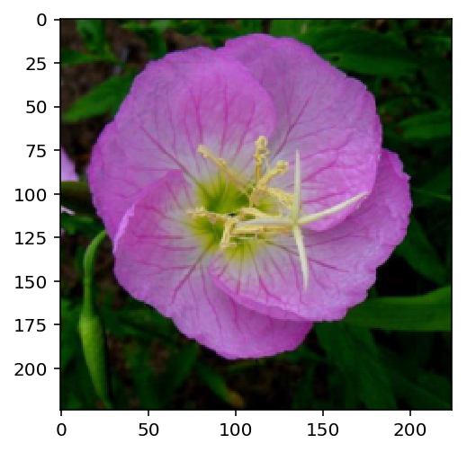

```python
# test a processed image
image_path = root_data_dir + testing_data_dir + "/1/image_06764.jpg"
processed_image = process_image(image_path)
imshow(torch.from_numpy(processed_image))
```

## Class Prediction

Once you can get images in the correct format, it's time to write a function for making predictions with your model. A common practice is to predict the top 5 or so (usually called top-$K$) most probable classes. You'll want to calculate the class probabilities then find the $K$ largest values.

To get the top $K$ largest values in a tensor use [`x.topk(k)`](http://pytorch.org/docs/master/torch.html#torch.topk). This method returns both the highest `k` probabilities and the indices of those probabilities corresponding to the classes. You need to convert from these indices to the actual class labels using `class_to_idx` which hopefully you added to the model or from an `ImageFolder` you used to load the data (see here). Make sure to invert the dictionary so you get a mapping from index to class as well.

Again, this method should take a path to an image and a model checkpoint, then return the probabilities and classes.

```
probs, classes = predict(image_path, model)
print(probs)
print(classes)
> [ 0.01558163  0.01541934  0.01452626  0.01443549  0.01407339]
> ['70', '3', '45', '62', '55']
```

```python
class_to_idx = saved_checkpoint['class_to_idx']
idx_to_class = {v : k for k, v in class_to_idx.items()}
```

```python
#Rubric: [Done] 14. Class Prediction
def predict(image_path, model, topk=5):
    # DONE: Implement the code to predict the class from an image file
    # load an image
    processed_image = process_image(image_path).squeeze()

    # turn off drop-out
    model.eval()

    # change to cuda
    model = model.cuda()

    print("Predicting the top {} classes with {} pre-trained model.".format(topk, model.__class__.__name__))

    with torch.no_grad():
        output = model(torch.from_numpy(processed_image).float().cuda().unsqueeze_(0))

    # Calculate the class probabilities (softmax) for image
    ps = nn_functional.softmax(output, dim=1)

    top = torch.topk(ps, topk)

    probabalities= top[0][0].cpu().numpy()
    classes = [idx_to_class[i] for i in top[1][0].cpu().numpy()]

    return probabalities, classes
```

## Sanity Checking

Now that you can use a trained model for predictions, check to make sure it makes sense. Even if the testing accuracy is high, it's always good to check that there aren't obvious bugs. Use `matplotlib` to plot the probabilities for the top 5 classes as a bar graph, along with the input image. It should look like this:

[figure not shown]

You can convert from the class integer encoding to actual flower names with the `cat_to_name.json` file (should have been loaded earlier in the notebook). To show a PyTorch tensor as an image, use the `imshow` function defined above.

```python
image_path = root_data_dir + testing_data_dir + "/75/image_02075.jpg"
image = Image.open(image_path)

probabilities, classes = predict(image_path, saved_model)
```

```
Predicting the top 5 classes with DenseNet pre-trained model.
```

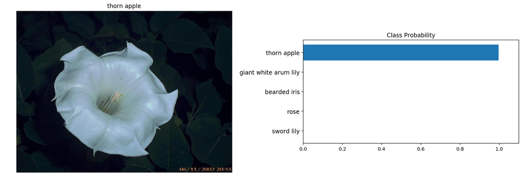

```python
# DONE: Display an image along with the top 5 classes
# Rubric: [Done] 15. Sanity Checking with matplotlib
fig, (ax1, ax2) = plt.subplots(figsize=(15, 15), ncols=2)
ax1.imshow(image)
ax1.axis('off')

ax2.barh(np.arange(5), probabilities)
ax2.set_aspect(0.1)
ax2.set_yticks(np.arange(5))

names = [cat_to_name[c] for c in classes]
ax1.set_title(names[0])

ax2.set_yticklabels(names, size='large')
ax2.set_title('Class Probability')
ax2.set_xlim(0, 1.1)
ax2.invert_yaxis()

plt.tight_layout()
```